# Basic Raster Analysis with R

Mitch Rudge

2022-02-24

## Basic Raster Analysis with R

[figure not shown]

What we will cover:

1. Raster and vector basics
2. Introducing the Terra package
3. Importing and exporting raster data
4. Dealing with coordinate reference systems
5. Raster data manipulation
6. Raster x Vector operations
7. Compatibility between Raster and Terra
8. Some applied examples
9. A fun new package called Layer!

What you will need: Installations of R, RStudio and Terra

## 1. Raster and vector basics.

**Rasters** divide areas into a grid of rectangles of equal size. Each rectangle holds one or more value for a variable of interest.

**Vectors** consist of a series of coordinates, which make points, lines or polygons.

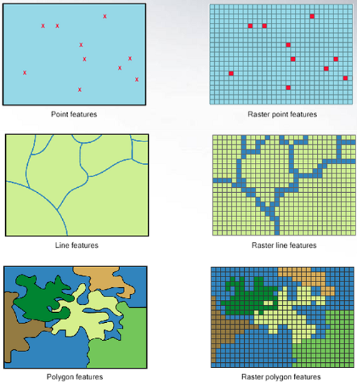

http://gsp.humboldt.edu/

## 2 Introducing the Terra package

[figure not shown]

Terra is set to replace the extremely popular Raster package. It is written by the same group of developers at [r spatial](https://github.com/rspatial), led by Robert Hijmans. This means that Terra is compatible with Raster - with some serious advantages.

**Advantages** of Terra over Raster. Faster. Unlike Raster, Terra is mostly written in C++, making it much faster for many operations.

Terra is also simpler than Raster, doing away with the complex data structure of Raster, like Raster layer vs stack vs brick. We will go into this later.

For now, lets install and load Terra.

```r
install.packages("terra")
library(terra)
```